# Appendix 2: Simulation Study

Chris Bentz

July 20, 2022

# Session Info

Give the session info (reduced).

```
## [1] "R version 3.6.3 (2020-02-29)"
```

```
## [1] "x86_64-pc-linux-gnu"
```

# Load Libraries

If the libraries are not installed yet, you need to install them using, for example, the command: install.packages(“ggplot2”).

```r
library(MASS)
library(ggplot2)
library(plyr)
library(dplyr)
library(GGally)
library(rstatix)
```

Give the package versions.

```
##  rstatix   GGally    dplyr     plyr  ggplot2     MASS
##  "0.7.0"  "2.1.2"  "1.0.7"  "1.8.6"  "3.3.5" "7.3-54"
```

# Introduction

The purpose of this file is to illustrate the decisions we take to statistically analyze the respective data, i.e. checking for normality of the data, choosing a statistical test for assessing equality in the mean values of two distributions, and getting effect sizes for this test. Both is achieved by using simulated data, i.e. pseudo-complexity measurements for two domains (e.g. syntax and morphology) across different languages. This also further illustrates the theoretical points made in the file on “theoretical background” with simulated data.

# Generate Correlated Data

We here generate correlated pseudo-complexity measurements for for a given number of languages $n$. The number of measurements per domain can also be chosen ($k$). We then apply standardization, as well as linear and non-linear transformations to illustrate how this impacts the results of correlation and mean value analyses.

```r
# set the seed for random number generation in order to
# get the same result when the code is re-run
set.seed(1)
# set parameters
n = 5 # number of languages
k = 10 # number of measures in domain
r = -0.9 # predefined correlation between the complexity values in the two domains
# generate the data
simulation.df <- data.frame()
for (i in 1:k){
  # generate two correlated samples
  data <- mvrnorm(n = n, mu = c(3, 3), Sigma = matrix(c(1, r, r, 1), nrow = 2),
                empirical = TRUE)
  # original values
  value.m <- data[, 1]
  value.s <- data[, 2]
  value <- c(value.m, value.s)
  # scaled original values
  value.m.scaled <- scale(value.m)
  value.s.scaled <- scale(value.s)
  value.scaled <- c(value.m.scaled, value.s.scaled)
  # add information about domain and measurement id
  domain <- c(rep("morphology", n), rep("syntax", n))
  measure <- rep(i, n)
  # create vector with language names
  language <- c()
  for (j in 1:n){
    language <- c(language, paste("language", j))
  }
  local.df <- data.frame(language, measure, domain, value, value.scaled)
  # linear transformation to syntax of language 1
  local.df$value.lt <- local.df$value
  local.df$value.lt[local.df$language == "language 1" &
                      local.df$domain == "syntax"] <-
  local.df$value.lt[local.df$language == "language 1" &
                      local.df$domain == "syntax"]*0.5
  # scale the data
  local.df$value.lt.scaled <-
    c(value.m.scaled, scale(local.df$value.lt[local.df$domain == "syntax"]))
  # non-linear transformation to syntax of language 2
  local.df$value.nt <- local.df$value
  local.df$value.nt[local.df$language == "language 2" &
                      local.df$domain == "syntax"] <-
  local.df$value.nt[local.df$language == "language 2" &
                      local.df$domain == "syntax"]^1.5
  # scale the data
  local.df$value.nt.scaled <-
    c(value.m.scaled, scale(local.df$value.nt[local.df$domain == "syntax"]))
  # bind to overall data frame
  simulation.df <- rbind(simulation.df, local.df)
}
```

Put into wide format (for scatterplots below).

```r
# wide format
simulation.df.wide <- reshape(simulation.df, idvar = c("language", "measure"),
                              timevar = "domain", direction = "wide")
# select only certain columns for plotting
simulation.df.short <- select(simulation.df.wide, value.morphology,
                              value.scaled.morphology, value.lt.syntax, value.nt.syntax,
                              value.scaled.syntax, value.lt.scaled.syntax,
                              value.nt.scaled.syntax)
```

# Scatterplot with Pearson Correlations

## For all the data

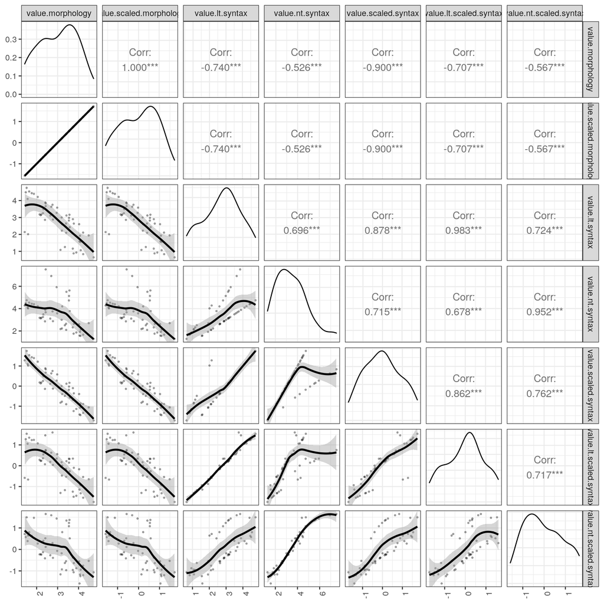

```r
simulation.scatterplot <- ggpairs(simulation.df.short,
                        lower = list(continuous = wrap("smooth_loess", alpha = 0.3,
                                                       lwd = 0.5, size = 2)),
                        upper = list(continuous = wrap('cor', method = "pearson"))) +
                        theme_bw() +
                        theme(axis.text.x = element_text(angle = 90, hjust = 1))
print(simulation.scatterplot)
```

## For selected parts of the data

Select the scaled morphological pseudo-complexity values, and the scaled syntactic pseudo-complexity values after non-linear transformation of the values of language 2. Note that for this data set we expect to find negative correlations *and* significant shifts in overall complexity vectors according to the proof in the appendix on the theoretical background.

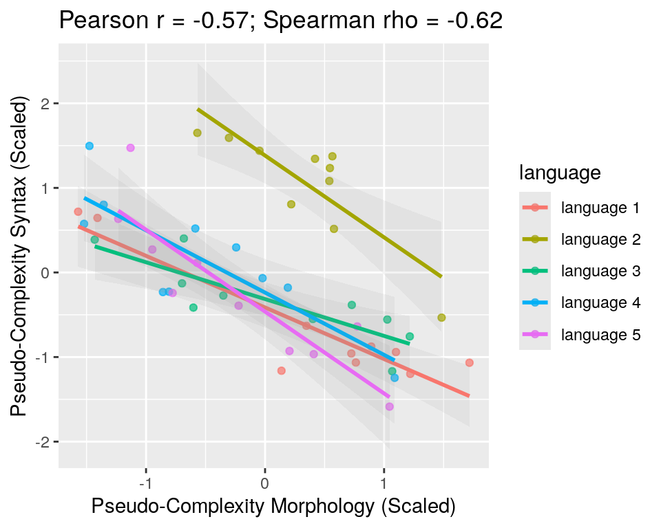

```r
scatterplot.selected <- ggplot(simulation.df.wide, aes(x = value.scaled.morphology,
                                                       y = value.nt.scaled.syntax,
                                                       color = language)) +
  geom_point(alpha = 0.7) +
  geom_smooth(method = lm, alpha = 0.1) +
  ggtitle("Pearson r = -0.57; Spearman rho = -0.62") +
  xlab("Pseudo-Complexity Morphology (Scaled)") +
  ylab("Pseudo-Complexity Syntax (Scaled)")
scatterplot.selected
```

# Density Distributions

## Standardized Samples

Get mean, median, and standard deviation values.

```r
# get mean values for each language
mu <- ddply(simulation.df, "language", summarise,
            grp.mean = mean(value.scaled, na.rm = T))
# get median values for each language
med <- ddply(simulation.df, "language", summarise,
             grp.median = median(value.scaled, na.rm = T))
# get standard deviation values for each language
sdev <- ddply(simulation.df, "language", summarise,
              grp.sd = sd(value.scaled, na.rm = T))
```

Plot density distributions with indication of median (mean) values.

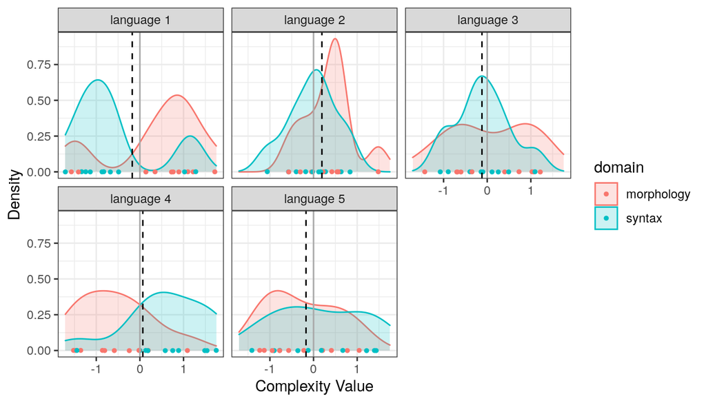

```r
density.plot <- ggplot(simulation.df, aes(x = value.scaled,
                                          color = domain, fill = domain)) +
  geom_density(alpha = .2) +
  # add some jitter to prevent overplotting
  geom_jitter(data = simulation.df, aes(x = value.scaled, y = 0),
             size = 1, height = 0.001, width = 0) +
  geom_vline(aes(xintercept = 0), color = "darkgrey") +
  geom_vline(data = med, aes(xintercept = grp.median), linetype = "dashed") +
  facet_wrap(~ language) +
  #xlim(-3, 3) +
  labs(x = "Complexity Value", y = "Density") +
  theme_bw()
print(density.plot)
```

## Standardized Samples with Non-Linear Transformation of Syntax Values

Get mean, median, and standard deviation values.

```r
# get mean values for each language
mu <- ddply(simulation.df, "language", summarise,
            grp.mean = mean(value.nt.scaled, na.rm = T))
# get median values for each language
med <- ddply(simulation.df, "language", summarise,
             grp.median = median(value.nt.scaled, na.rm = T))
# get standard deviation values for each language
sdev <- ddply(simulation.df, "language", summarise,
              grp.sd = sd(value.nt.scaled, na.rm = T))
```

Plot density distributions with indication of median (mean) values.

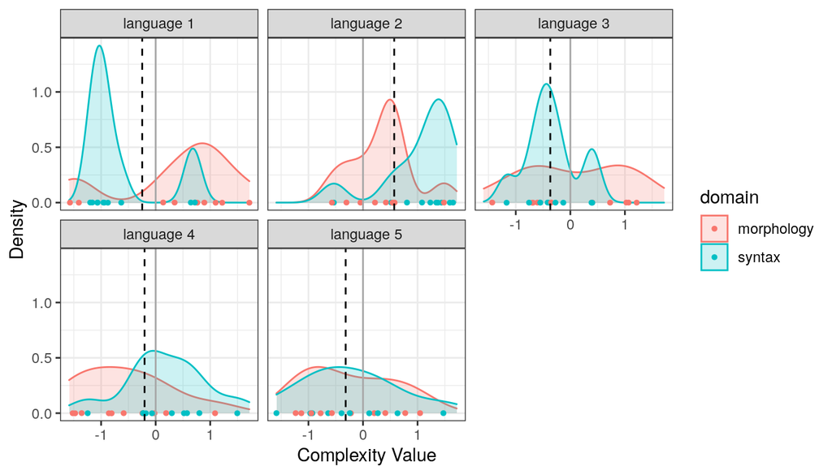

```r
density.plot <- ggplot(simulation.df, aes(x = value.nt.scaled,
                                          color = domain, fill = domain)) +
  geom_density(alpha = .2) +
  # add some jitter to prevent overplotting
  geom_jitter(data = simulation.df, aes(x = value.nt.scaled, y = 0),
             size = 1, height = 0.001, width = 0) +
  geom_vline(aes(xintercept = 0), color = "darkgrey") +
  geom_vline(data = med, aes(xintercept = grp.median), linetype = "dashed") +
  facet_wrap(~ language) +
  #xlim(-3, 3) +
  labs(x = "Complexity Value", y = "Density") +
  theme_bw()
print(density.plot)
```

## Normality

Check for normality of the data via QQ-plots. The dots should roughly follow a straight line (Crawley 2007, p. 281).

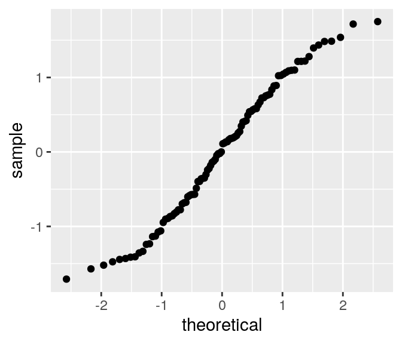

```r
# standardized samples
ggplot(simulation.df, aes(sample = value.scaled)) +
  stat_qq()
```

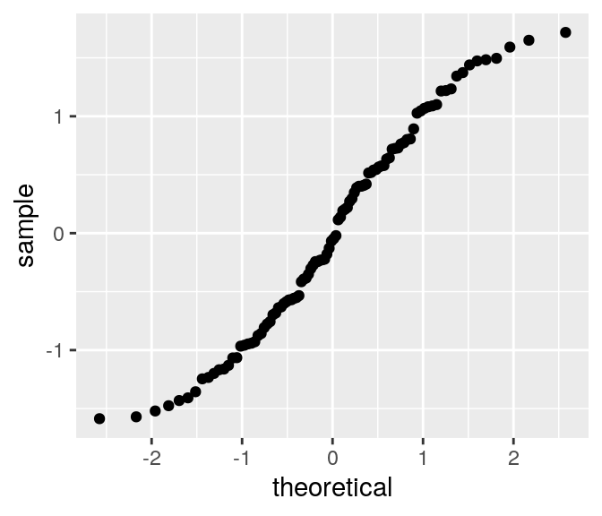

```r
# standardized samples with non-linear transformation of syntax values
ggplot(simulation.df, aes(sample = value.nt.scaled)) +
  stat_qq()
```

## Choose statistical tests

Select a statistical test: We choose the Wilcoxon signed rank test here as a non-parametric alternative to the t-test (Crawley 2007, p. 283; Baayen 2008, p. 77). The data is “paired” here since we generated pseudo-complexity measures for all languages and domains.

Run pairwise Wilcoxon tests for the standardized original values.

```r
# we add some random noise here to the value vector with
# the function jitter(), since we otherwise get warnings due to ties in the data
p.values <- pairwise.wilcox.test(jitter(simulation.df$value.scaled),
                                 simulation.df$language, paired = T,
                                 p.adjust.method = "holm")
p.values$p.value
```

```
##            language 1 language 2 language 3 language 4
## language 2          1         NA         NA         NA
## language 3          1          1         NA         NA
## language 4          1          1          1         NA
## language 5          1          1          1          1
```

Run pairwise Wilcoxon tests for the standardized values with non-linear transformation of syntactic values.

```r
p.values <- pairwise.wilcox.test(jitter(simulation.df$value.nt.scaled),
                                 simulation.df$language, paired = T,
                                 p.adjust.method = "holm")
p.values$p.value
```

```
##            language 1 language 2 language 3 language 4
## language 2  0.1864929         NA         NA         NA
## language 3  1.0000000 0.06646729         NA         NA
## language 4  1.0000000 0.01016617          1         NA
## language 5  1.0000000 0.02092552          1          1
```

# Effect Size

An overview of effect size measures per statistical test is given in Patil (2020). In conjunction with the Wilcoxon test we use the statistic r (i.e. function wilcox_effsize() of the “rstatix” package).

```r
# standardized original
effect.sizes <- wilcox_effsize(simulation.df, value.scaled ~ language, paired = T)
# standardized with non-linear transformation of syntactic values
effect.sizes.nt <- wilcox_effsize(simulation.df, value.nt.scaled ~ language, paired = T)
```

# Effect Size Heatmap

Plot heatmaps with effect sizes to get a better overview.

## Standardized

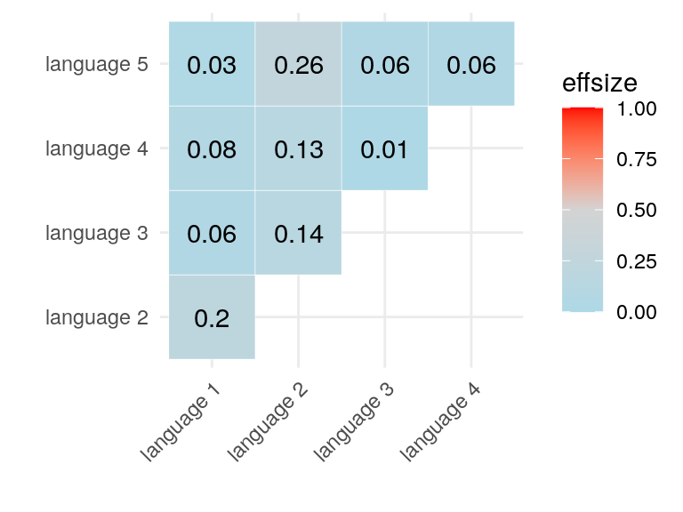

```r
effect.sizes.plot <- ggplot(as.data.frame(effect.sizes), aes(group1, group2)) +
  geom_tile(aes(fill = effsize), color = "white") +
  scale_fill_gradient2(low = "light blue", mid = "light grey", high = "red",
                       midpoint = 0.5, limit = c(0,1)) +
  geom_text(aes(label = round(effsize, 2))) +
  labs(x = "", y = "") +
  theme_minimal() +
  theme(axis.text.x = element_text(angle = 45, hjust = 1))
effect.sizes.plot
```

## Standardized with non-linear transformation of syntactic values

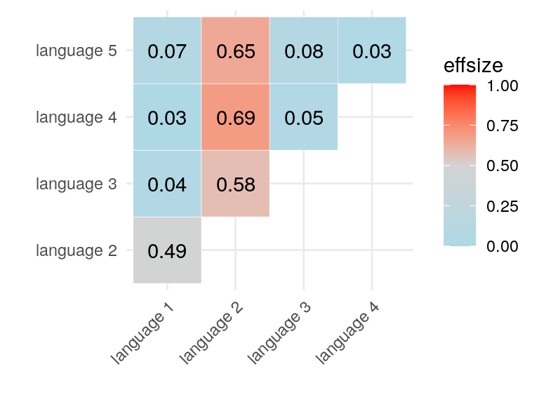

```r
effect.sizes.nt.plot <- ggplot(as.data.frame(effect.sizes.nt), aes(group1, group2)) +
  geom_tile(aes(fill = effsize), color = "white") +
  scale_fill_gradient2(low = "light blue", mid = "light grey", high = "red",
                       midpoint = 0.5, limit = c(0,1)) +
  geom_text(aes(label = round(effsize, 2))) +
  labs(x = "", y = "") +
  theme_minimal() +
  theme(axis.text.x = element_text(angle = 45, hjust = 1))
effect.sizes.nt.plot
```

# Interpretation

Firstly, we can see in the correlation plots that we consistently find negative and significant Pearson and Spearman correlations between morphological and syntactic pseudo-complexity values across languages.

Notice that for the standardized original data we also find no significant differences between any pair of languages in the Wilcoxon tests (p=1 for all pairs), and the effect sizes are in the range 0.01 to 0.26, i.e. small. However, for the data where we have a non-linear transformation of the syntactic pseudo-complexity values in language 2, we now find some significant differences in the Wilcoxon test (i.e. p < 0.05 for comparisons of language 2 with language 4 and 5), and these are matched with large effect sizes (i.e. 0.69 and 0.65).

This simulation hence corroborates the points of the proof in the appendix on ``theoretical background’’. Namely, for standardized data with no transformations (or linear transformations) the link between negative correlations and equality of overall complexity holds. However, for data with non-linear transformations of pseudo-complexity values (here for language 2) this link breaks: we are able to detect significant shifts in the overall complexity location of language 2 despite the negative correlations in the domains.

# References

Baayen, R. H. (2008). Analyzing linguistic data: A practical introduction using statistics in R. Cambridge University Press.

Crawley, M. J. (2007). The R book. John Wiley & Sons Ltd.

Patil, I. (2020). Test and effect size details. online at https://cran.r-project.org/web/packages/statsExpressions/vignettes/stats_details.html.